# Salmon Temperature Model

Austin, Alexander, and Savannah

May 9, 2019

Model is first completed using input data from 2018. This shows us the relative contribution of temperature sources in the system.

Later the individual parameters are changed to understand how changes to the system may impact temperature: - increased release of water from dworshack August-October - temperature decrease on the Snake River (decrease by 2 degrees) - if air temp increase by 2 degrees C, how much does that change warming in the reservoir

# Step 1: Cold Water is released from Dworshack Dam and generates power

## Load libraries and data

```r
library(tidyverse)
library(readr)
library(lubridate)
library(readxl)
```

```r
#load elevation data
dworshack_elv <- read_csv("../Data/dworshack_elv.csv")
#load flow data
dworshack_flow <- read_xls("../Data/dworshack_flow.xls") %>%
  mutate(date = ymd(date)) %>%
  mutate_at(vars(date), funs(year, month, day)) %>%
  filter(year == 2018)
```

## Calculate power generation model inputs

### Calculate head and convert from ft to m

head (ft) = forebay elevation (ft) - tailwater elevation (ft)

```r
# create new column that calculates head and remove NAs
dworshack_head <- dworshack_elv %>%
  mutate(head = (forebay_elv - tailwater_elv)) %>%
  select(date, head) %>%
  na.omit()

# convert head from ft to m
dworshack_head <- mutate(dworshack_head, head_m = dworshack_head$head*0.305)

dworshack_head$date <- as.Date(dworshack_head$date, "%m/%d/%Y")
```

### Calculate flow for power generation and convert to m3/s

This could be an input parameter (observed data exists), but then there would be no change in power generation when outflow values are changed.

flow availabile for power generation (kcfs) = total outflow (kcfs) - spill (kcfs) - losses(kcfs)

```r
#create column with flows avaialble for power generation assuming 5% loss

perc_loss = 0.05 #start with 5% loss


power_flow <- dworshack_flow %>%
  mutate(calc_power_flow = (total_outflow - spill_flow)) %>%
  mutate(losses = calc_power_flow*perc_loss) %>%
  mutate(power_flow_wlosses = calc_power_flow - losses)

#convert kcfs to m3/s
power_flow <- power_flow %>%
  select(date, total_outflow, spill_flow, power_flow_wlosses) %>%
  mutate(total_outflow_m3s = (total_outflow * 28.32)) %>%
  mutate(spill_flow_m3s = spill_flow * 28.32) %>%
  mutate(power_flow_wlosses_m3s = power_flow_wlosses * 28.32)
```

### Merge final historic data inputs for power gneration at Dworshack into single data frame

```r
# keep flow inputs with correct units
flow_inputs <- power_flow %>%
  select(date, total_outflow_m3s, spill_flow_m3s, power_flow_wlosses_m3s)

head_inputs <- dworshack_head %>%
  select(date, head_m) %>%
  mutate(date = ymd(date)) %>%
  mutate_at(vars(date), funs(year, month, day)) %>%
  filter(year == 2018)

historic_inputs <- merge(flow_inputs, head_inputs, by = "date")
historic_inputs$date <- as.Date(historic_inputs$date, "%m/%d/%Y")
```

## Run power generation model

```r
source("../R/dshack_powergen.R")

test_data <- historic_inputs %>%
  select(date, power_flow_wlosses_m3s, head_m) %>%
  mutate(date = ymd(date)) %>%
  mutate_at(vars(date), funs(year, month, day)) %>%
  filter(year == 2018)

reservoir_model_res= as.data.frame(matrix(nrow=365, ncol=4))
colnames(reservoir_model_res)=c("date", "head","flowrate","power")

reservoir_model_res$date = test_data$date
reservoir_model_res$head = test_data$head_m
reservoir_model_res$flowrate = test_data$power_flow_wlosses_m3s


reservoir_model_res$power = mapply(FUN=max_power, head =reservoir_model_res$head, flow=reservoir_model_res$flowrate)


#umultiply final result by 2.5. Theere are 3 generators/turbines in the dam. They are not always operational and not always at full capactiy. The value of 2.5 provides a good match to observed data.
reservoir_model_res <- mutate(reservoir_model_res, power_MW = ((power/100000)*2.5))
```

# Step 2: Water from Dworshack dam (the North Fork of the Clearwater River) mixes with the mainstem of the Clearwater River

```r
library(tidyverse)
library(readr)
library(readxl)
library(lubridate)
```

```r
temp_data <- read_excel("../Data/temp_flow_data.xlsx",
    sheet = "temp", col_types = c("date",
        "numeric", "numeric", "numeric"))

#North Fork Clearwater flows (release from Dworshack) come from Dworshack flows data in step 1
flow_data <- read_excel("../Data/temp_flow_data.xlsx",
    sheet = "flow", col_types = c("date",
        "numeric", "numeric", "numeric"))



temp_18 <- temp_data %>%
  mutate(date = ymd(Date)) %>%
  mutate_at(vars(Date), funs(year, month, day)) %>%
  filter(year == 2018)

flow_18 <- flow_data %>%
  mutate(date = ymd(Date)) %>%
  mutate_at(vars(Date), funs(year, month, day)) %>%
  filter(year == 2018)
```

# Mix North fork of clearwater with south fork of clearwater

```r
source("../R/mix.R")

cw_mix_results <- as.data.frame(matrix(nrow=365, ncol=3))
colnames(cw_mix_results)=c("date","mix_cw_flow", "mix_cw_temp")

cw_mix_results$date <- temp_18$Date

cw_mixmod = mapply(FUN=mix, Q1=flow_18$nfork_cw, Q2 = flow_18$sfork_cw, T1 = temp_18$nfork_cw, T2 = temp_18$sfork_cw)

mix_res = as.data.frame(matrix(unlist(cw_mixmod), ncol=2, byrow=T))
colnames(mix_res) = c("temp", "flow")

cw_mix_results$mix_cw_temp <- mix_res$temp
cw_mix_results$mix_cw_temp <- round(cw_mix_results$mix_cw_temp, 2)
cw_mix_results$mix_cw_flow <- mix_res$flow


#view results
cw_mix_results
```

```
##           date mix_cw_flow mix_cw_temp
## 1   2018-01-01       11990        3.02
## 2   2018-01-02       10350        2.99
## 3   2018-01-03        9400        3.06
## 4   2018-01-04        6450        1.87
## 5   2018-01-05        6250        2.14
## 6   2018-01-06        6320        2.77
## 7   2018-01-07        6750        3.12
## 8   2018-01-08        6710        3.27
## 9   2018-01-09        7330        3.33
## 10  2018-01-10       12000        3.04
## 11  2018-01-11       11160        3.15
## 12  2018-01-12       13600        3.32
## 13  2018-01-13       14800        3.49
## 14  2018-01-14       13700        3.94
```

[output cut: 351 more lines]

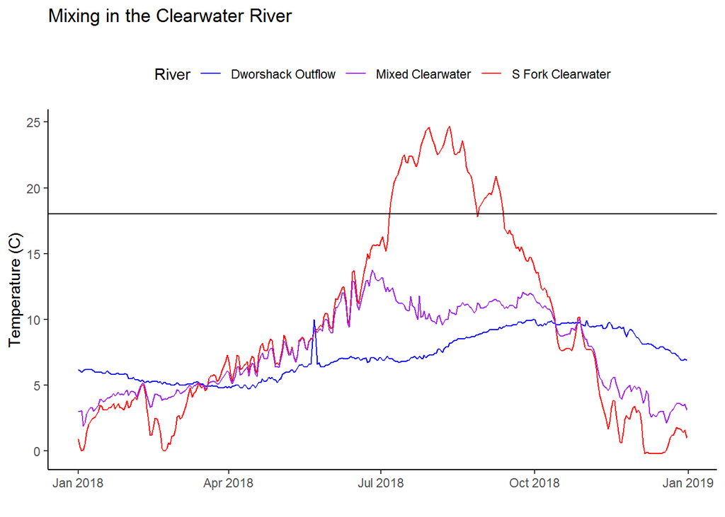

```r
#plot temperature with river segments

ggplot() +
  geom_line(data = temp_18, aes(x= Date, y= nfork_cw, color = "Dworshack Outflow")) +
  geom_line(data = temp_18, aes(x= Date, y= sfork_cw, color = "S Fork Clearwater")) +
  geom_line(data = cw_mix_results, aes(x= date, y= mix_cw_temp, color = "Mixed Clearwater")) +
  geom_hline(yintercept= 18)+
  xlab("") +
  ylab("Temperature (C)") +
  ggtitle("Mixing in the Clearwater River\n") +
  theme_classic()+
  scale_color_manual(name = "River", values = c("blue", "purple", "red"))+
  theme(legend.position = "top")
```

# Mix the mixed Clear Water with lower Snake

```r
#mixing
snake_mix_results <- as.data.frame(matrix(nrow=365, ncol=3))
colnames(snake_mix_results)=c("date","mix_sn_flow", "mix_sn_temp")

snake_mix_results$date <- temp_18$Date

snake_mixmod = mapply(FUN=mix, Q1=flow_18$snake, Q2 = cw_mix_results$mix_cw_flow, T1 = temp_18$snake, T2 = cw_mix_results$mix_cw_temp)

mix_res_snake = as.data.frame(matrix(unlist(snake_mixmod), ncol=2, byrow=T))
colnames(mix_res_snake) = c("temp", "flow")


snake_mix_results$mix_sn_temp <- mix_res_snake$temp
snake_mix_results$mix_sn_temp <- round(snake_mix_results$mix_sn_temp, 2)
snake_mix_results$mix_sn_flow <- mix_res_snake$flow


snake_mix_results
```

```
##           date mix_sn_flow mix_sn_temp
## 1   2018-01-01       41190        3.36
## 2   2018-01-02       40650        3.30
## 3   2018-01-03       38000        3.47
## 4   2018-01-04       36450        3.38
## 5   2018-01-05       36850        3.77
## 6   2018-01-06       38620        4.30
## 7   2018-01-07       39150        4.43
## 8   2018-01-08       37010        4.44
## 9   2018-01-09       38530        4.52
## 10  2018-01-10       45300        4.33
## 11  2018-01-11       46560        4.25
## 12  2018-01-12       49200        4.10
## 13  2018-01-13       52800        4.50
## 14  2018-01-14       49700        4.56
```

[output cut: 351 more lines]

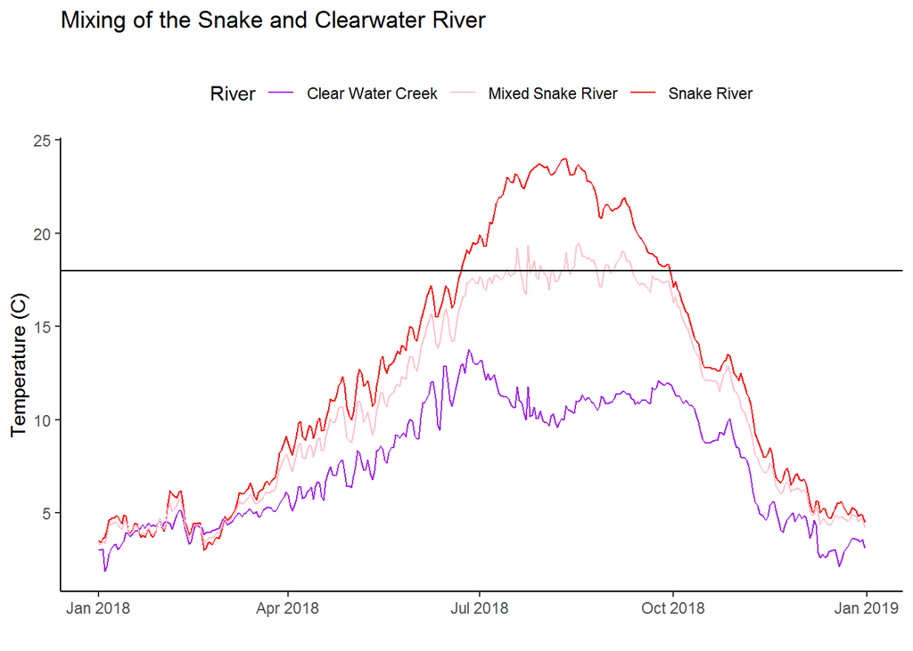

```r
#plot with river segments

ggplot() +
  geom_line(data = temp_18, aes(x= Date, y= snake, color = "Snake River")) +
  geom_line(data = cw_mix_results, aes(x= date, y= mix_cw_temp, color = "Clear Water Creek")) +
  geom_line(data = snake_mix_results, aes(x= date, y= mix_sn_temp, color = "Mixed Snake River")) +
  xlab("") +
  ylab("Temperature (C)") +
  ggtitle("Mixing of the Snake and Clearwater River\n") +
  geom_hline(yintercept= 18)+
  theme_classic()+
  scale_color_manual(name = "River", values = c("purple", "pink", "red"))+
  theme(legend.position = "top")
```

# Warming in the Lower Granite Reservoir

```r
#warming in lower granite reservoir
#load function
source("../R/air_warming.R")

#load air temperature data
lewiston_temp <- read_csv("../Data/lewiston_climate_data.csv")
```

```r
#convert air temperature to celsius
lewiston_temp$Ta_avg <- round((lewiston_temp$TAVG-32)*(5/9), 2)

#filter for just 2018 data
air_temp <- lewiston_temp %>%
  filter(YEAR == 2018) %>%
  select(Ta_avg)

#run function to determine change in water temperature from reservoir heat fluxes
lg_airmod = air_warming(Tw = snake_mix_results$mix_sn_temp, Ta = air_temp, flow = snake_mix_results$mix_sn_flow)

#make water temperature change results into a dataframe
lg_air_chg_temp = round(unlist(lg_airmod[[1]]), 2)

#populate the results matrix we created to include flow, water temperature change, and final water temperature (in temperature plus change)
lg_air_results <- as.data.frame(matrix(nrow=365, ncol=4))
colnames(lg_air_results)=c("date", "flow", "lg_temp_chg", "lg_temp_final")

lg_air_results$date <- snake_mix_results$date
lg_air_results$flow <- snake_mix_results$mix_sn_flow
lg_air_results$lg_temp_chg <- lg_air_chg_temp
lg_air_results$lg_temp_final <- snake_mix_results$mix_sn_temp + lg_air_results$lg_temp_chg

#view results
lg_air_results
```

```
##           date   flow lg_temp_chg lg_temp_final
## 1   2018-01-01  41190        0.07          3.43
## 2   2018-01-02  40650        0.10          3.40
## 3   2018-01-03  38000        0.12          3.59
## 4   2018-01-04  36450        0.11          3.49
## 5   2018-01-05  36850        0.23          4.00
## 6   2018-01-06  38620        0.27          4.57
## 7   2018-01-07  39150        0.26          4.69
## 8   2018-01-08  37010        0.48          4.92
## 9   2018-01-09  38530        0.46          4.98
## 10  2018-01-10  45300        0.35          4.68
## 11  2018-01-11  46560        0.23          4.48
## 12  2018-01-12  49200        0.31          4.41
## 13  2018-01-13  52800        0.32          4.82
## 14  2018-01-14  49700        0.33          4.89
```

[output cut: 351 more lines]

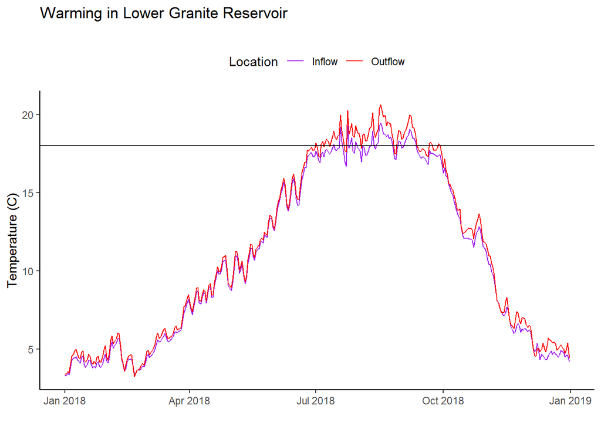

```r
#plot temperature output
ggplot(lg_air_results) +
  geom_line(data = snake_mix_results, aes(x = date, y = mix_sn_temp, color = "Inflow")) +
  geom_line(aes(x = date, y = lg_temp_final, color = "Outflow")) +
  xlab("") +
  ylab("Temperature (C)") +
  ggtitle("Warming in Lower Granite Reservoir\n") +
  geom_hline(yintercept= 18)+
  theme_classic()+
  scale_color_manual(name = "Location", values = c("purple", "red"))+
  theme(legend.position = "top")
```

```r
#export final data
write.csv(lg_air_results, "baseline.csv")
```

# Relative Temperature Contributions

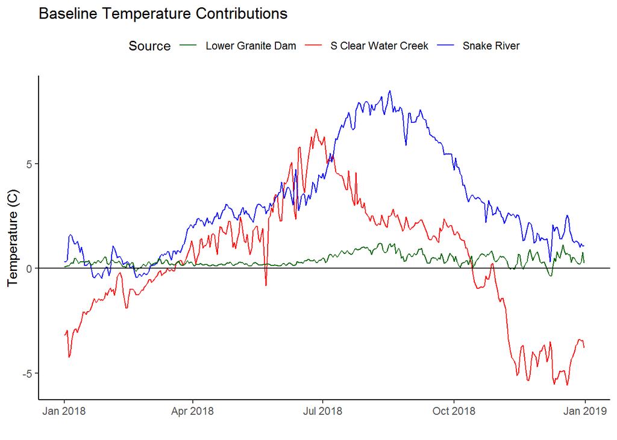

```r
#S Clear Water Creek Contribution
relative_contrib <- as.data.frame(matrix(nrow=365, ncol=4))
colnames(relative_contrib)=c("date", "s_cwc_contrib", "snake_contrib", "lg_contrib")

relative_contrib$date = lg_air_results$date
relative_contrib$s_cwc_contrib = cw_mix_results$mix_cw_temp - temp_18$nfork_cw
relative_contrib$snake_contrib = snake_mix_results$mix_sn_temp - cw_mix_results$mix_cw_temp
relative_contrib$lg_contrib = lg_air_results$lg_temp_chg

#graph
ggplot(relative_contrib) +
  geom_line(aes(x = date, y = s_cwc_contrib, color = "S Clear Water Creek")) +
  geom_line(aes(x = date, y = snake_contrib, color = "Snake River")) +
  geom_line(aes(x = date, y = lg_contrib, color = "Lower Granite Dam")) +
  geom_hline(yintercept= 0)+
  xlab("") +
  ylab("Temperature (C)") +
  ggtitle("Baseline Temperature Contributions") +
  theme_classic()+
  scale_color_manual(name = "Source", values = c("dark green", "red", "blue"))+
  theme(legend.position = "top")
```